# Wildlife Presence Using Trail Cameras

Riley Robenstein

2025-12-08

# 1 Remote sensing and wildlife

Use of remote sensing in wildlife research has become increasingly prevalent, particularly with trail cameras. Trail cameras can provide information about wildlife presence and absence when human observations are unavailable or may disturb wildlife activity and presence. Continued collection of data with trail cameras can provide spatial and temporal trends of larger wildlife. The SNAPSHOT USA project contains several years of camera trap data across the US available for public use (Rooney et al. 2025*b*). Data were collected using un-baited cameras and identified through [Wildlife Insights](https://app.wildlifeinsights.org/initiatives/2000156/Snapshot-USA). The objective of this project is to become familiar with trail camera data to assess wildlife presence and activity. This will ultimately help in future data collection using trail cameras and acoustic recording units deployed and point count surveys conducted in the University of Idaho Experimental Forest to assess how deadwood structures may influence wildlife presence and activity. This file assists in building a database and cleaning and visualizing trail camera data.

## 1.1 SNAPSHOT USA

SNAPSHOT USA is a national project where camera trap surveys are conducted across all 50 US states annually from September-October to estimate wildlife abundance and distributions (Rooney et al. 2025*a*). This project primarily focuses on mammalian species, with large birds also included. SNAPSHOT USA’s protocol provides a solid base for community science, and various organizations across the country collaborate to produce these spatial and temporal wildlife data. Some contributors have provided data outside the standard collection period, so the 2019-2023 data span from August 1-December 29 (Rooney et al. 2025*a*). Each collaborator is required to deploy a camera array made up of a minimum of eight un-baited cameras. The SNAPSHOT USA protocol requires at least 400 camera trap-nights between September and October per year for each camera array (Rooney et al. 2025*a*).

## 1.2 Study area

My focal area included a total of 15 trail camera sites in Idaho, Washington, and Oregon (Figure 1).

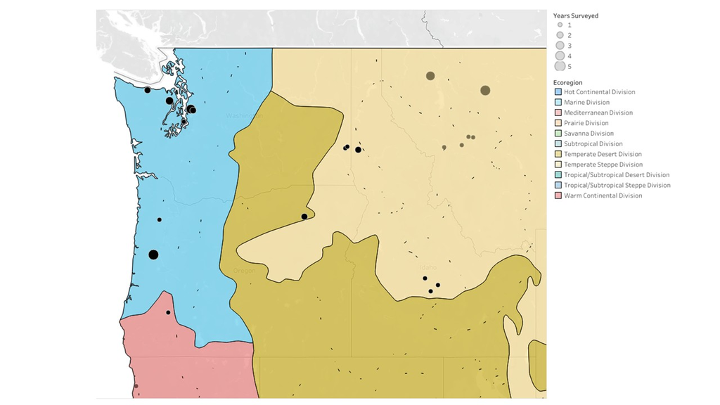

Figure 1. Camera array locations and Bailey’s ecoregions of the US from 2019-2023. Darker points represent locations that fall within Idaho, Washington and Oregon and size correlates to the number of years surveyed. Colored polygons represent different ecoregions.

## 1.3 Data description

I subsetted these data to only include cameras deployed in Idaho, Washington and Oregon. Data consisted of camera arrays, camera locations, general habitat characteristics, deployment periods, image sequences, and taxonomic information across various levels for species identification (Rooney et al. 2025*b*). Further information regarding camera array locations and ecoregions were added for camera arrays (Rooney 2024).

## 1.4 References

Rooney, B. 2024. Years of data collected by camera arrays. <https://public.tableau.com/app/profile/brigit.rooney/viz/YearsofDataCollectedbyCameraArrays/Sheet6>.

Rooney, B., R. Kays, M. V. Cove, A. Jensen, B. R. Goldstein, C. Pate, P. Castiblanco, M. E. Abell, J. Adley, B. Agenbroad, et al. 2025*a*. SNAPSHOT USA 2019-2023: The first five years of data from a coordinated camera trap survey of the united states. Global Ecology and Biogeography 34:e13941. <https://onlinelibrary.wiley.com/doi/full/10.1111/geb.13941>.

Rooney, B., W. McShea, R. Kays, and M. Cove. 2025*b*. SNAPSHOT USA 2019-2023: the first five years of data from a coordinated camera trap survey of the United States [Dataset]. Dryad. <https://datadryad.org/dataset/doi:10.5061/dryad.k0p2ngfhn>.

# 2 Database creation and population

Trail camera data were distributed across six `.csv` files in the **processed_data** folder to optimize storage and data manipulation. I created a relational database with R and SQL to easily navigate these data (Figure 2). Note that the header of each box corresponds to the name of each table. The database can be reproduced with the code in sections **2.1-2.8**.

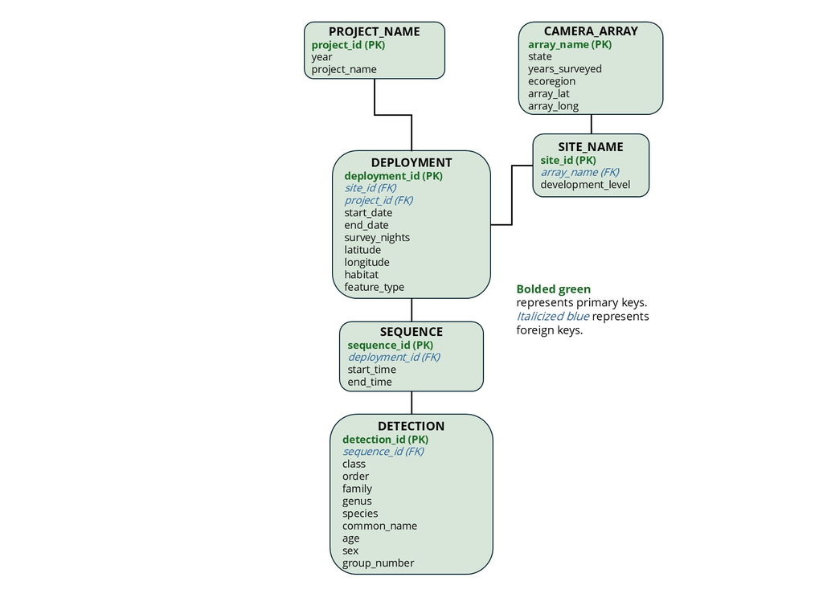

Figure 2. Entity relationship diagram of relational database structure.

## 2.1 Load packages and create and connect to database

Load the packages `DBI` and `RSQLite` required to connect R and SQLite. Use `install.packages()` if the packages are not installed.

```r
library(DBI)
library(RSQLite)
```

Connect to the database file. A database file will be created if the code has not previously been executed.

```r
wlf_cam_db <- dbConnect(drv = RSQLite::SQLite(),
                       "../database/wlf_cam.db")
```

## 2.2 **PROJECT_NAME** table

The **project_name** table includes the following variables: project_id (**primary key**), project_name, and year, where project_id is a unique identifier for each unique project by year, project name is the respective project name, and year is the year data were captured.

### 2.2.1 Create **project_name** table

Create the table in SQLite.

```r
dbExecute(conn = wlf_cam_db,
          statement = "CREATE TABLE project_name (
          project_id varchar(10) PRIMARY KEY NOT NULL UNIQUE,
          project_name varchar(35),
          year numeric(4) CHECK (year IN
                                          ('2019',
                                          '2020',
                                          '2021',
                                          '2022',
                                          '2023'))
          );")
```

### 2.2.2 Populate **project_name** table

Populate this database table with the `.csv` file after checking the column names correspond.

```r
# Read in project_name.csv file
project_name_csv <- read.csv("../processed_data/project_name.csv")

# Get .csv column names
colnames(project_name_csv)
# Get database field names
dbListFields(wlf_cam_db, "project_name")

# Append .csv into SQLite table
dbWriteTable(conn = wlf_cam_db,
             name = "project_name",
             value = project_name_csv,
             append = TRUE)
```

## 2.3 **CAMERA_ARRAY** table

The **camera_array** table includes the following variables: array_name (**primary key**), state, years_surveyed, ecoregion, array_lat, and array_long, where array_name is a unique identifier for each camera trap array, state is the US state where the array was located, years_surveyed is the number of years an array has image sequence data from, ecoregion is based on Bailey’s ecoregions (Bailey 2016 as cited in Rooney et al. 2025) and array_lat and array_long are the approximate latitude and longitude coordinates (decimal degrees WGS 84) for the respective array array.

### 2.3.1 Create **camera_array** table

Create the table in SQLite.

```r
dbExecute(conn = wlf_cam_db,
          statement = "CREATE TABLE camera_array (
          array_name varchar(20) PRIMARY KEY NOT NULL UNIQUE,
          state varchar(2),
          years_surveyed numeric(1),
          ecoregion varchar(20),
          array_lat numeric(10, 10),
          array_long numeric(10, 10)
          );")
```

### 2.3.2 Populate **camera_array** table

Populate this database table with the `.csv` file after checking the column names correspond.

```r
# Read in camera_array.csv file
camera_array_csv <- read.csv("../processed_data/camera_array.csv")

# Get .csv column names
colnames(camera_array_csv)
# Get database field names
dbListFields(wlf_cam_db, "camera_array")

# Append .csv into SQLite table
dbWriteTable(conn = wlf_cam_db,
             name = "camera_array",
             value = camera_array_csv,
             append = TRUE)
```

## 2.4 **SITE_NAME** table

The **site_name** table includes the following variables: site_id (**primary key**), array_name (*foreign key*), and development_level, where site_id is a unique identifier for each site, array_name corresponds to the array_name in camera_array, and development_level is classified as wild, rural, suburban, or urban.

### 2.4.1 Create **site_name** table

Create the table in SQLite.

```r
dbExecute(conn = wlf_cam_db,
          statement = "CREATE TABLE site_name (
          site_id varchar(50) PRIMARY KEY NOT NULL UNIQUE,
          array_name  varchar(50),
          development_level varchar(10) CHECK (development_level IN
                                                                ('Wild',
                                                                'Rural',
                                                                'Urban',
                                                                'Suburban')),
          FOREIGN KEY (array_name) REFERENCES camera_array(array_name)
          );")
```

### 2.4.2 Populate **site_name** table

Populate this database table with the `.csv` file after checking the column names correspond.

```r
# Read in site_name.csv file
site_name_csv <- read.csv("../processed_data/site_name.csv")

# Get .csv column names
colnames(site_name_csv)
# Get database field names
dbListFields(wlf_cam_db, "site_name")

# Append .csv into SQLite table
dbWriteTable(conn = wlf_cam_db,
             name = "site_name",
             value = site_name_csv,
             append = TRUE)
```

## 2.5 **DEPLOYMENT** table

The **deployment** table includes the following variables: deployment_id (**primary key**), site_id (*foreign key*), project_id (*foreign key*). start_date, end_date, survey_nights, latitude, longitude, habitat, and feature type, where deployment_id is a unique identifier for each camera deployment, site_id corresponds to the site_id in site_name, project_id corresponds to the project_id in project_name, start_date is the date (*YYYY-MM-DD*) when the camera was deployed, end_date is the date (*YYYY-MM-DD*) when the camera was retrieved, survey_nights is number of nights the camera was at the site, latitude and longitude are geographic coordinates (decimal degrees WGS 84) between 21.3558 to 59.4526 and -157.7496 to -68.6116, respectively, habitat is classified as forest, grassland, or anthropogenic, and feature type indicates potential features at the camera’s deployment site.

### 2.5.1 Create **deployment** table

Create the table in SQLite.

```r
dbExecute(conn = wlf_cam_db,
          statement = "CREATE TABLE deployment (
          deployment_id varchar(60) PRIMARY KEY NOT NULL UNIQUE,
          site_id varchar(50),
          project_id varchar(10),
          start_date text,
          end_date text,
          survey_nights numeric (3),
          latitude numeric(10, 10),
          longitude numeric(10, 10),
          habitat varchar(15),
          feature_type varchar(15),
          FOREIGN KEY (site_id) REFERENCES site_name(site_id)
          FOREIGN KEY (project_id) REFERENCES project_name(project_id)
          );")
```

### 2.5.2 Populate **deployment** table

Populate this database table with the `.csv` file after checking the column names correspond.

```r
# Read in deployment.csv file
deployment_csv <- read.csv("../processed_data/deployment.csv")

# Get .csv column names
colnames(deployment_csv)
# Get database field names
dbListFields(wlf_cam_db, "deployment")
```

Before populating the table, note the discrepancy in names of variables.

```
##  [1] "deployment_id" "site_id"       "project_id"    "lat"
##  [5] "long"          "start"         "end"           "survey_nights"
##  [9] "habitat"       "feature_type"
```

```
##  [1] "deployment_id" "site_id"       "project_id"    "start_date"
##  [5] "end_date"      "survey_nights" "latitude"      "longitude"
##  [9] "habitat"       "feature_type"
```

Edit the `.csv` column names to fit those of the database first.

```r
# Edit .csv column names
colnames(deployment_csv) <- c("deployment_id", "site_id",
                              "project_id", "latitude",
                              "longitude", "start_date",
                              "end_date", "survey_nights",
                              "habitat", "feature_type")

# Check .csv column names again
colnames(deployment_csv)
```

```
##  [1] "deployment_id" "site_id"       "project_id"    "latitude"
##  [5] "longitude"     "start_date"    "end_date"      "survey_nights"
##  [9] "habitat"       "feature_type"
```

Now that the column names match, populate the deployment table.

```r
# Append .csv into SQLite table
dbWriteTable(conn = wlf_cam_db,
             name = "deployment",
             value = deployment_csv,
             append = TRUE)
```

## 2.6 **SEQUENCE** table

The **sequence** table includes the following variables: sequence_id (**primary key**), deployment_id (*foreign key*), start_time, and end_time, where sequence_id is a unique identifier for each photo sequence captured within one minute of a camera trigger, deployment_id corresponds to the deployment_id in deployment, start_time is the beginning of the one-minute photo sequence, and end_time is the end of the one-minute photo sequence.

### 2.6.1 Create **sequence** table

Create the table in SQLite.

```r
dbExecute(conn = wlf_cam_db,
          statement = "CREATE TABLE sequence (
          sequence_id varchar(15) PRIMARY KEY NOT NULL UNIQUE,
          deployment_id varchar(60),
          start_time text,
          end_time text,
          FOREIGN KEY (deployment_id) REFERENCES deployment(deployment_id)
          );")
```

### 2.6.2 Populate **sequence** table

Populate this database table with the `.csv` file after checking the column names correspond.

```r
# Read in sequence.csv file
sequence_csv <- read.csv("../processed_data/sequence.csv")

# Get .csv column names
colnames(sequence_csv)
# Get database field names
dbListFields(wlf_cam_db, "sequence")

# Append .csv into SQLite table
dbWriteTable(conn = wlf_cam_db,
             name = "sequence",
             value = sequence_csv,
             append = TRUE)
```

## 2.7 **DETECTION** table

The **detection** table includes the following variables: detection_id (**primary key**), sequence_id (*foreign key*), class, order, family, genus, species, common_name, age, sex, and group_number, where detection_id is a unique identifier for each wildlife detection, sequence_id corresponds to the sequence_id in sequence, class is the taxonomic class identified for the wildlife detection, order is the taxonomic order identified for the wildlife detection, family is the taxonomic family identified for the wildlife detection, genus is the taxonomic genus identified for the wildlife detection, species is the taxonomic species identified for the wildlife detection, common_name is the common name identified for the wildlife detection, age is classified as juvenile or adult, sex is classified as male or female, and group_number is the number of individuals in the image sequence with that respective taxonomic identification.

### 2.7.1 Create **detection** table

Create the table in SQLite.

```r
dbExecute(conn = wlf_cam_db,
          statement = "CREATE TABLE detection (
          detection_id varchar(15) PRIMARY KEY NOT NULL UNIQUE,
          sequence_id varchar(15),
          class varchar(15),
          'order' varchar(20),
          family varchar(20),
          genus varchar (15),
          species varchar(15),
          common_name varchar(30),
          age varchar(10),
          sex varchar(10),
          group_number numeric(2),
          FOREIGN KEY (sequence_id) REFERENCES sequence(sequence_id)
          );")
```

### 2.7.2 Clean **detection** table

The detection `.csv` file has missing values and formatting is inconsistent. To ensure they are compatible with `SQLite` and `R`, load the `.csv` file and convert all missing values to ‘NA’. Make formatting consistent for the variables *age* and *sex*.

```r
# Read in detection.csv file
detection_csv <- read.csv("../processed_data/detection.csv")

# Convert ' ' or 'Unknown' values to blank ('')
detection_csv[detection_csv == " " | detection_csv == "Unknown" | detection_csv == "unknown"] <- NA

# Make formatting consistent
detection_csv$age[detection_csv$age == "adult"] <- "Adult"
detection_csv$age[detection_csv$age == "juvenile"] <- "Juvenile"

detection_csv$sex[detection_csv$sex == "male"] <- "Male"
detection_csv$sex[detection_csv$sex == "female"] <- "Female"
```

### 2.7.3 Populate **detection** table

Populate this database table with the `.csv` file after checking the column names correspond.

```r
# Get .csv column names
colnames(detection_csv)
# Get database field names
dbListFields(wlf_cam_db, "detection")

# Append .csv into SQLite table
dbWriteTable(conn = wlf_cam_db,
             name = "detection",
             value = detection_csv,
             append = TRUE)
```

## 2.8 Check database

Run the following code to ensure the data were loaded into the tables properly.

```r
# List table names

dbListTables(wlf_cam_db)
```

```
## [1] "camera_array" "deployment"   "detection"    "project_name" "sequence"
## [6] "site_name"
```

```r
# project_name table

dbGetQuery(wlf_cam_db, "SELECT * FROM project_name
                        LIMIT 5;")
```

```
##   project_id      project_name year
## 1    ssusa19 Snapshot USA 2019 2019
## 2    ssusa20 Snapshot USA 2020 2020
## 3    ssusa21 Snapshot USA 2021 2021
## 4    ssusa22 Snapshot USA 2022 2022
## 5    ssusa23 Snapshot USA 2023 2023
```

```r
# camera_array table

dbGetQuery(wlf_cam_db, "SELECT * FROM camera_array
                        LIMIT 5;")
```

```
##       array_name state years_surveyed        ecoregion array_lat array_long
## 1         Galena    ID              1 Temperate Steppe     43.86    -114.65
## 2         Hailey    ID              1 Temperate Steppe     43.56    -114.47
## 3      SunValley    ID              1 Temperate Steppe     43.70    -114.22
## 4 OregonStateUni    OR              5           Marine     44.42    -123.46
## 5      Forrester    OR              2 Temperate Desert     45.29    -118.56
```

```r
# site_name table

dbGetQuery(wlf_cam_db, "SELECT * FROM site_name
                        LIMIT 5;")
```

```
##                            site_id array_name development_level
## 1 OR_Forest_Forrester_21_loc_01dup  Forrester              Wild
## 2    OR_Forest_Forrester_21_loc_02  Forrester              Wild
## 3    OR_Forest_Forrester_21_loc_03  Forrester              Wild
## 4    OR_Forest_Forrester_21_loc_04  Forrester              Wild
## 5    OR_Forest_Forrester_21_loc_05  Forrester              Wild
```

```r
# deployment table

dbGetQuery(wlf_cam_db, "SELECT * FROM deployment
                        LIMIT 5;")
```

```
##                   deployment_id                          site_id
## 1 OR_Forest_Forrester_21_dep_01 OR_Forest_Forrester_21_loc_01dup
## 2 OR_Forest_Forrester_21_dep_02    OR_Forest_Forrester_21_loc_02
## 3 OR_Forest_Forrester_21_dep_03    OR_Forest_Forrester_21_loc_03
## 4 OR_Forest_Forrester_21_dep_04    OR_Forest_Forrester_21_loc_04
## 5 OR_Forest_Forrester_21_dep_05    OR_Forest_Forrester_21_loc_05
##          project_id start_date   end_date survey_nights latitude longitude
## 1 Snapshot USA 2021   9/1/2021 11/24/2021            84 45.30501 -118.6071
## 2 Snapshot USA 2021   9/1/2021 11/24/2021            84 45.30404 -118.5949
## 3 Snapshot USA 2021   9/1/2021  11/5/2021            65 45.30509 -118.5822
## 4 Snapshot USA 2021   9/1/2021  11/5/2021            65 45.30507 -118.5695
## 5 Snapshot USA 2021   9/1/2021 10/28/2021            57 45.30468 -118.5566
##   habitat feature_type
## 1  Forest   Trail game
## 2  Forest   Trail game
## 3  Forest   Trail game
## 4  Forest   Trail game
## 5  Forest    Road dirt
```

```r
# sequence table

dbGetQuery(wlf_cam_db, "SELECT * FROM sequence
                        LIMIT 5;")
```

```
##   sequence_id        deployment_id      start_time        end_time
## 1    sewa0001 SEWA_N01_DSPSS1_SP22 9/12/2022 17:57 9/12/2022 17:59
## 2    sewa0002 SEWA_N01_DSPSS1_SP22  9/14/2022 7:59  9/14/2022 8:01
## 3    sewa0003 SEWA_N01_DSPSS1_SP22  9/14/2022 8:02  9/14/2022 8:02
## 4    sewa0004 SEWA_N01_DSPSS1_SP22  9/15/2022 5:17  9/15/2022 5:17
## 5    sewa0005 SEWA_N01_DSPSS1_SP22  9/16/2022 1:32  9/16/2022 1:33
```

```r
# detection table

dbGetQuery(wlf_cam_db, "SELECT * FROM detection
                        LIMIT 5;")
```

```
##   detection_id sequence_id    class    order    family genus species
## 1      cd00001     7446823 Mammalia Primates Hominidae  Homo sapiens
## 2      cd00002     7446946 Mammalia Primates Hominidae  Homo sapiens
## 3      cd00003     7447030 Mammalia Primates Hominidae  Homo sapiens
## 4      cd00004     7447116 Mammalia Primates Hominidae  Homo sapiens
## 5      cd00005     7447141 Mammalia Primates Hominidae  Homo sapiens
##            common_name  age  sex group_number
## 1 Human-Camera Trapper <NA> <NA>            1
## 2 Human-Camera Trapper <NA> <NA>            1
## 3                Human <NA> <NA>            1
## 4                Human <NA> <NA>            1
## 5                Human <NA> <NA>            1
```

# 3 Data exploration

Now that the database is created and loaded, we can explore and familiarize ourselves with trail camera data.

## 3.1 Load package and tables

Load the `tidyverse` package to help with data exploration. Load the tables from the database and assign them each to an object.

```r
library(tidyverse)

project <- dbGetQuery(wlf_cam_db, "SELECT * FROM project_name;")
array <- dbGetQuery(wlf_cam_db, "SELECT * FROM camera_array;")
site <- dbGetQuery(wlf_cam_db, "SELECT * FROM site_name;")
deployment <- dbGetQuery(wlf_cam_db, "SELECT * FROM deployment;")
sequence <- dbGetQuery(wlf_cam_db, "SELECT * FROM sequence;")
detection <- dbGetQuery(wlf_cam_db, "SELECT * FROM detection;")
```

## 3.2 Exploratory summaries

Before diving into wildlife presence/absence and population trends, explore the following summary information about the trail cameras below.

### 3.2.1 Deployments per year

We want to know how many cameras were deployed each year.

```r
n_cam <- deployment %>%
  mutate(year = year(mdy(start_date))) %>% # acquire year from deployment date
  group_by(year) %>% # group deployments by year
  tally # calculate number of cameras deployed per year

n_cam
```

```
## # A tibble: 5 × 2
##    year     n
##   <dbl> <int>
## 1  2019    65
## 2  2020    61
## 3  2021    67
## 4  2022   116
## 5  2023    93
```

### 3.2.2 Arrays with > 8 cameras

We want to know how many camera arrays had more than eight cameras deployed per survey period.

Note that there is no foreign key directly connecting the array and deployment tables. We will need the site table to connect these these two tables.

```r
n_array <- array %>%
  left_join(site, by = "array_name") %>% # join site table to array using array_name
  left_join(deployment, by = "site_id") %>% # join deployment table to array using site_id
  mutate(year = year(mdy(start_date)), # acquire year from deployment date
         array_year = paste0(array_name, "_", year)) %>% # create new variable with array name and year
  group_by(array_year) %>%
  tally %>%  # calculate number of cameras per array per year
  filter(n > 8) %>% # include arrays with more than 8 cameras
  tally # calculate number of arrays with > 8 cameras deployed in a survey period

n_array
```

```
## # A tibble: 1 × 1
##       n
##   <int>
## 1    25
```

We can see that 25 camera array deployments had more than eight cameras.

### 3.2.3 Sites reused

We want to know how many and which sites were reused.

```r
reused <- site %>%
  left_join(deployment, by = "site_id") %>% # join deployment table to site using site_id
  group_by(site_id) %>% # group by site
  tally %>% # calculate number of times each site is used
  filter(n > 1) # include sites with more than one deployment

n_reused <- tally(reused) # calculate number of sites reused

reused
```

```
## # A tibble: 40 × 2
##    site_id                                           n
##    <chr>                                         <int>
##  1 DRPSS1                                            3
##  2 DSPSS1                                            3
##  3 IRPSS1                                            5
##  4 JBPSS1                                            4
##  5 LTPSS1                                            3
##  6 LWPSS1                                            3
##  7 MGPSS1                                            4
##  8 NRPSS1                                            3
##  9 OR_Forest_Oregon_State_University_22_ORSNAP07     2
## 10 Oregon_Forest_Lesmeister_21_loc_01                4
## # ℹ 30 more rows
```

```r
n_reused
```

```
## # A tibble: 1 × 1
##       n
##   <int>
## 1    40
```

We can see that 40 sites were reused between 2019-2023 in Idaho, Washington and Oregon.

## 3.3 Number of species

Now, let’s look at the species level.

### 3.3.1 By habitat

We want to know how many species were detected in each habitat type. Similar to before, we will need to bring in a third table—sequence—to relate the detection and deployment tables.

```r
# filter out NA values for species
sp_detect <- detection[!is.na(detection$species), ]

n_sp_habitat <- sp_detect[sp_detect$species != "sapiens", ] %>% # filter out detections of humans
  filter(!grepl("Domestic", common_name)) %>% # filter out domestic animals
  left_join(sequence, by = "sequence_id") %>% # join sequence table to detection using sequence_id
  left_join(deployment, by = "deployment_id") %>% # join deployment table to detection using deployment_id
  mutate(genus_species = paste0(genus, " ", species)) %>% # create new variable with genus and species
  select(genus_species, habitat) %>%  # select variables genus_species and habitat
  group_by(habitat) %>% # group by habitat
  tally

n_sp_habitat
```

```
## # A tibble: 3 × 2
##   habitat           n
##   <chr>         <int>
## 1 Anthropogenic  3538
## 2 Forest        10467
## 3 Grassland       371
```

### 3.3.2 By feature type

We want to know how many species were detected near each feature type. Like the previous query, we will need the sequence table to relate the detection and deployment tables.

```r
# filter out NA values for species
sp_detect <- detection[!is.na(detection$species), ]

n_sp_feature <- sp_detect[sp_detect$species != "sapiens", ] %>% # filter out detections of humans
  filter(!grepl("Domestic", common_name)) %>% # filter out domestic animals
  left_join(sequence, by = "sequence_id") %>% # join sequence table to detection using sequence_id
  left_join(deployment, by = "deployment_id") %>% # join deployment table to detection using deployment_id
  mutate(genus_species = paste0(genus, " ", species)) %>% # create new variable with genus and species
  select(genus_species, feature_type) %>%  # select variables genus_species and feature_type
  group_by(feature_type) %>% # group by feature_type
  tally

n_sp_feature
```

```
## # A tibble: 6 × 2
##   feature_type     n
##   <chr>        <int>
## 1 None         11219
## 2 Other          763
## 3 Road dirt      297
## 4 Trail game    1239
## 5 Trail hiking   730
## 6 Water source   128
```

### 3.3.3 By habitat and feature type

We want to know how many species were detected in each habitat type near each feature type.

```r
# filter out NA values for species
sp_detect <- detection[!is.na(detection$species), ]

n_species <- sp_detect[sp_detect$species != "sapiens", ] %>% # filter out detections of humans
  filter(!grepl("Domestic", common_name)) %>% # filter out domestic animals
  left_join(sequence, by = "sequence_id") %>% # join sequence table to detection using sequence_id
  left_join(deployment, by = "deployment_id") %>% # join deployment table to detection using deployment_id
  mutate(genus_species = paste0(genus, " ", species)) %>% # create new variable with genus and species
  select(genus_species, habitat, feature_type) %>%  # select variables genus_species, habitat, and feature_type
  group_by(habitat, feature_type) %>% # group by habitat, then feature_type
  tally

n_species
```

```
## # A tibble: 11 × 3
## # Groups:   habitat [3]
##    habitat       feature_type     n
##    <chr>         <chr>        <int>
##  1 Anthropogenic None          2979
##  2 Anthropogenic Trail game     257
##  3 Anthropogenic Trail hiking   302
##  4 Forest        None          8240
##  5 Forest        Other          736
##  6 Forest        Road dirt      297
##  7 Forest        Trail game     766
##  8 Forest        Trail hiking   428
##  9 Grassland     Other           27
## 10 Grassland     Trail game     216
## 11 Grassland     Water source   128
```

## 3.4 Number of detections

Let’s look at the individual level for wildlife detections.

### 3.4.1 By year

We want to know how many individuals—known and unknown—were detected each year.

```r
wlf_detect <- detection
wlf_detect$species[is.na(wlf_detect$species)] <- "unknown" # convert NA values to "unknown"

n_detect_yr <- wlf_detect[wlf_detect$species != "sapiens", ] %>% # filter out detections of humans
  filter(!grepl("Domestic", common_name)) %>% # filter out domestic animals
  left_join(sequence, by = "sequence_id") %>% # join sequence table to detection using sequence_id
  mutate(year = year(mdy_hm(start_time))) %>% # acquire year from start sequence
  select(group_number, year) %>%  # select variables group_number and year
  group_by(year) %>% # group by year
  summarise(n = sum(group_number))

n_detect_yr
```

```
## # A tibble: 5 × 2
##    year     n
##   <dbl> <int>
## 1  2019  4425
## 2  2020  3780
## 3  2021  1816
## 4  2022  4696
## 5  2023  4699
```

We want to know how many known individuals were detected each year.

```r
known_detect <- detection[!is.na(detection$species), ] # filter out unknown (NA) detections

n_known_yr <- known_detect[known_detect$species != "sapiens", ] %>% # filter out detections of humans
  filter(!grepl("Domestic", common_name)) %>% # filter out domestic animals
  left_join(sequence, by = "sequence_id") %>% # join sequence table to detection using sequence_id
  mutate(year = year(mdy_hm(start_time))) %>% # acquire year from start sequence
  select(group_number, year) %>%  # select variables group_number and year
  group_by(year) %>% # group by year
  summarise(n = sum(group_number))

n_known_yr
```

```
## # A tibble: 5 × 2
##    year     n
##   <dbl> <int>
## 1  2019  3432
## 2  2020  2886
## 3  2021  1618
## 4  2022  3917
## 5  2023  3841
```

### 3.4.2 By month

We want to know how many individuals—known and unknown—were detected each month to assess at a more seasonal level.

```r
wlf_detect <- detection
wlf_detect$species[is.na(wlf_detect$species)] <- "unknown" # convert NA values to "unknown"

n_detect_m <- wlf_detect[wlf_detect$species != "sapiens", ] %>% # filter out detections of humans
  filter(!grepl("Domestic", common_name)) %>% # filter out domestic animals
  left_join(sequence, by = "sequence_id") %>% # join sequence table to detection using sequence_id
  mutate(month = month(mdy_hm(start_time))) %>% # acquire month from start sequence
  select(group_number, month) %>%  # select variables group_number and year
  group_by(month) %>% # group by year
  summarise(n = sum(group_number))

n_detect_m
```

```
## # A tibble: 4 × 2
##   month     n
##   <dbl> <int>
## 1     8   761
## 2     9  8884
## 3    10  8862
## 4    11   909
```

```r
known_detect <- detection[!is.na(detection$species), ] # filter out unknown (NA) detections

n_known_m <- known_detect[known_detect$species != "sapiens", ] %>% # filter out detections of humans
  filter(!grepl("Domestic", common_name)) %>% # filter out domestic animals
  left_join(sequence, by = "sequence_id") %>% # join sequence table to detection using sequence_id
  mutate(month = month(mdy_hm(start_time))) %>% # acquire month from start sequence
  select(group_number, month) %>%  # select variables group_number and month
  group_by(month) %>% # group by month
  summarise(n = sum(group_number))

n_known_m
```

```
## # A tibble: 4 × 2
##   month     n
##   <dbl> <int>
## 1     8   672
## 2     9  7343
## 3    10  6943
## 4    11   736
```

### 3.4.3 By site

We want to know which sites had the highest number of known individuals detected. Let’s focus on the top five sites. Note that we need to bring in the deployment and sequence tables to relate the site and detection tables.

```r
known_detect <- detection[!is.na(detection$species), ] # filter out unknown (NA) detections

known_detect <- known_detect[known_detect$species != "sapiens", ] # filter out human detections

n_detect_site <- site %>%
  left_join(deployment, by = "site_id") %>% # join deployment table to site using site_id
  left_join(sequence, by = "deployment_id") %>% # join sequence table to site using deployment_id
  left_join(known_detect, by = "sequence_id") %>%  # join detection table to site using sequence_id
  filter(!grepl("Domestic", common_name)) %>% # filter out domestic animals
  select(group_number, site_id) %>%  # select variables group_number and month
  group_by(site_id) %>% # group by month
  summarise(n = sum(group_number, na.rm = TRUE)) %>% # calculate number of individuals detected per site
  arrange(desc(n)) # arrange in descending order of individuals detected

head(n_detect_site, 5) # display the 5 sites with highest number of detections
```

```
## # A tibble: 5 × 2
##   site_id     n
##   <chr>   <int>
## 1 IRPSS1    725
## 2 JBPSS1    531
## 3 LTPSS1    511
## 4 RVPSS1    394
## 5 DSPSS1    342
```

### 3.4.4 By site and month

We want to know which sites had the highest number of known individuals detected in September and October. Again, let’s focus on the top five sites. We need to bring in the deployment table to relate the detection-sequence and site tables.

```r
known_detect <- detection[!is.na(detection$species), ] # filter out unknown (NA) detections

known_detect <- known_detect[known_detect$species != "sapiens", ] # filter out human detections

n_detect <- site %>%
  left_join(deployment, by = "site_id") %>% # join deployment table to site table using site_id
  left_join(sequence, by = "deployment_id") %>% # join sequence table to site using deployment_id
  left_join(known_detect, by = "sequence_id") %>%  # join detection table to site using sequence_id
  filter(!grepl("Domestic", common_name)) %>% # filter out domestic animals
  mutate(month = month(mdy_hm(start_time))) %>% # acquire month from start sequence
  filter(month %in% c(9, 10)) %>% # only include detections from Sept and Oct
  select(group_number, month, site_id) %>% # select variables group_number, month, and site_id
  group_by(site_id, month) %>% # group by site_id, then by month
  summarise(n = sum(group_number, na.rm = TRUE)) # calculate number of individuals detected per site per month

Sept <- n_detect[n_detect$month == 9, ] %>%
  arrange(desc(n)) # arrange in descending order of individuals detected
Oct <- n_detect[n_detect$month == 10, ] %>%
  arrange(desc(n)) # arrange in descending order of individuals detected

head(Sept, 5)
```

```
## # A tibble: 5 × 3
## # Groups:   site_id [5]
##   site_id month     n
##   <chr>   <dbl> <int>
## 1 JBPSS1      9   355
## 2 IRPSS1      9   310
## 3 LTPSS1      9   298
## 4 DSPSS1      9   204
## 5 RVPSS1      9   190
```

```r
head(Oct, 5)
```

```
## # A tibble: 5 × 3
## # Groups:   site_id [5]
##   site_id                 month     n
##   <chr>                   <dbl> <int>
## 1 IRPSS1                     10   368
## 2 LTPSS1                     10   213
## 3 SEWA_N01_LTPSS_SP20_OFF    10   203
## 4 RVPSS1                     10   195
## 5 JBPSS1                     10   168
```

# 4 Data visualization

Begin visualizing trends seen in the camera trap data. To use the same color scheme shown, run `devtools::install_github("cdanielcadena/tanagR")` and load the package `tanagR`.

```r
library(tanagR)
```

## 4.1 Species in September and October

We want to know the number of individuals in each species detected in September and October. There are many species observed throughout these data, so we will break down the detections as we go.

```r
# filter out NA values for species
sp_detect <- detection[!is.na(detection$species), ]

sp_month <- sp_detect[sp_detect$species != "sapiens", ] %>% # filter out detections of humans
  filter(!grepl("Domestic", common_name)) %>% # filter out domestic animals
  left_join(sequence, by = "sequence_id") %>% # join sequence table to detection using sequence_id
  mutate(genus_species = paste0(genus, " ", species), # create new variable with genus and species
         month = month(mdy_hm(start_time), label = TRUE, abbr = FALSE)) %>% # acquire month from start sequence
  filter(month %in% c("September", "October")) %>% # only include detections from Sept and Oct
  group_by(month, common_name) %>% # group by month, then common_name
  select(order, family, genus_species, group_number, common_name, month) # select variables genus_species, group_number, and habitat
```

### 4.1.1 Species detected > 100 times

Let’s visualize this for species with more than 100 detections in September or October.

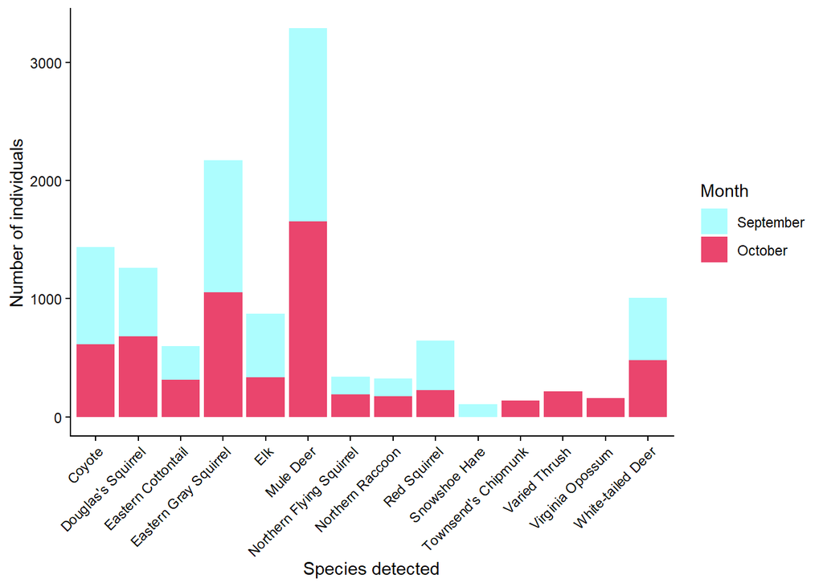

```r
mult_detect <- sp_month %>%
  group_by(month, common_name) %>%
  summarize(n_individuals = sum(group_number)) %>% # calculate number of individuals detected per species per month
  filter(n_individuals > 100) # select species detected > 100 times

ggplot(mult_detect, aes(x = common_name, y = n_individuals, fill = month)) +
  geom_bar(stat = "identity") +
  labs(x = "Species detected", y = "Number of individuals", fill = "Month") +
  scale_fill_tanagr(palette_name = "cyanerpes_cyaneus") +
  theme_classic() +
  theme(axis.text.x = element_text(angle = 45, hjust = 1, vjust = 1))
```

### 4.1.2 Carnivora order detections

Focusing on the order Carnivora, we want to visualize the number of individuals in each species detected in September and October.

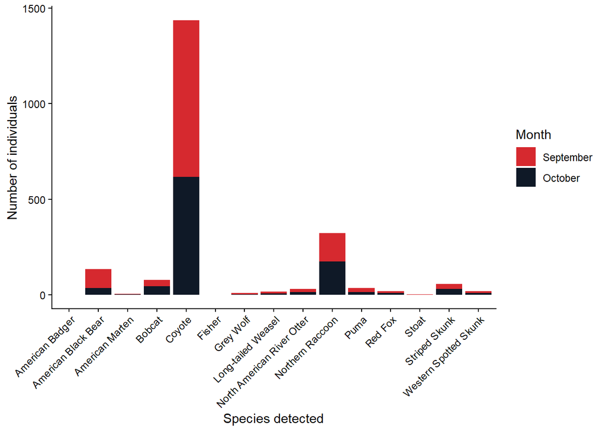

```r
carnivora <- sp_month[sp_month$order == "Carnivora", ] %>% # select species in order Carnivora
  group_by(month, common_name) %>%
  summarize(n_individuals = sum(group_number)) # calculate number of individuals detected per species per month

ggplot(carnivora, aes(x = common_name, y = n_individuals, fill = month)) +
  geom_bar(stat = "identity") +
  labs(x = "Species detected", y = "Number of individuals", fill = "Month") +
  scale_fill_tanagr(palette_name = "ramphocelus_sanguinolentus") +
  theme_classic() +
  theme(axis.text.x = element_text(angle = 45, hjust = 1, vjust = 1))
```

## 4.2 Detections across orders

Many detections were only identified to the order level. Rather than looking at the species level, we want to visualize the number of individuals in each order detected in September and October.

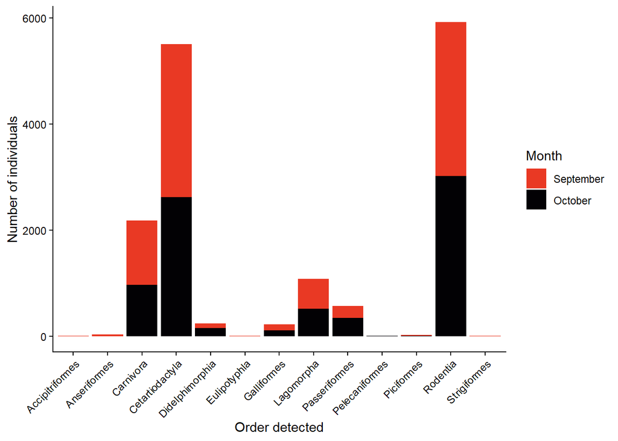

```r
wlf_detect <- detection
wlf_detect$species[is.na(wlf_detect$species)] <- "unknown" # convert NA values to "unknown"

n_order <- wlf_detect[wlf_detect$species != "sapiens", ] %>% # filter out detections of humans
  filter(!grepl("Domestic", common_name)) %>% # filter out domestic animals
  left_join(sequence, by = "sequence_id") %>% # join sequence table to detection using sequence_id
  mutate(month = month(mdy_hm(start_time),
                       label = TRUE, abbr = FALSE)) %>% # acquire month from start sequence
  filter(month %in% c("September", "October"), # only include detections from Sept and Oct
         !is.na(order)) %>% # remove NAs
  group_by(month, order) %>% # group by month, then order
  summarise(n_individuals = sum(group_number))  # calculate number of individuals detected per order per month

ggplot(n_order, aes(x = order, y = n_individuals, fill = month)) +
  geom_bar(stat = "identity") +
  labs(x = "Order detected", y = "Number of individuals", fill = "Month") +
  scale_fill_tanagr(palette_name = "tangara_chilensis") +
  theme_classic() +
  theme(axis.text.x = element_text(angle = 45, hjust = 1, vjust = 1))
```

## 4.3 Detections over time

We want to visualize wildlife trends over time in a couple of ways. Let’s break this down again to help understand the bigger picture.

```r
detect_wlf <- detection
detect_wlf$term[!grepl("Domestic", detect_wlf$common_name)] <- "wildlife"
detect_wlf$term[detect_wlf$common_name != "sapiens"] <- "wildlife"
  # define non-human and non-domestic life as wildlife in new column 'term'

detect_wlf$term[detect_wlf$species == "sapiens"] <- "human-domestic"
  # define humans as human or domestic life
detect_wlf$term[detect_wlf$common_name == "Domestic Cat"] <- "human-domestic"
  # define domestic cats as human or domestic life
detect_wlf$term[detect_wlf$common_name == "Domestic Cattle"] <- "human-domestic"
  # define domestic cattle as human or domestic life
detect_wlf$term[detect_wlf$common_name == "Domestic Dog"] <- "human-domestic"
  # define domestic dogs as human or domestic life
detect_wlf$term[detect_wlf$common_name == "Domestic Horse"] <- "human-domestic"
  # define domestic horses as human or domestic life
detect_wlf$term[detect_wlf$common_name == "Domestic Sheep"] <- "human-domestic"
  # define domestic sheep as human or domestic life

detect_wlf <- detect_wlf[!is.na(detect_wlf$common_name), ]
  # remove wildlife undefined in the common_name

sp_time <- detect_wlf %>%
  left_join(sequence, by = "sequence_id") %>% # join sequence table to detection using sequence_id
  left_join(deployment, by = "deployment_id") %>% # join deployment table to detection using deployment_id
  mutate(date = mdy(format(mdy_hm(start_time), "%m-%d-%Y")), # acquire date from start sequence
         year = year(mdy_hm(start_time)), # acquire year from start sequence
         julian_day = date) # begin building julian day

year(sp_time$julian_day) <- 2000 # set year to be the same for all julian days
```

### 4.3.1 Wildlife detections over time

We want to visualize the number of individuals detected over time and compare across years.

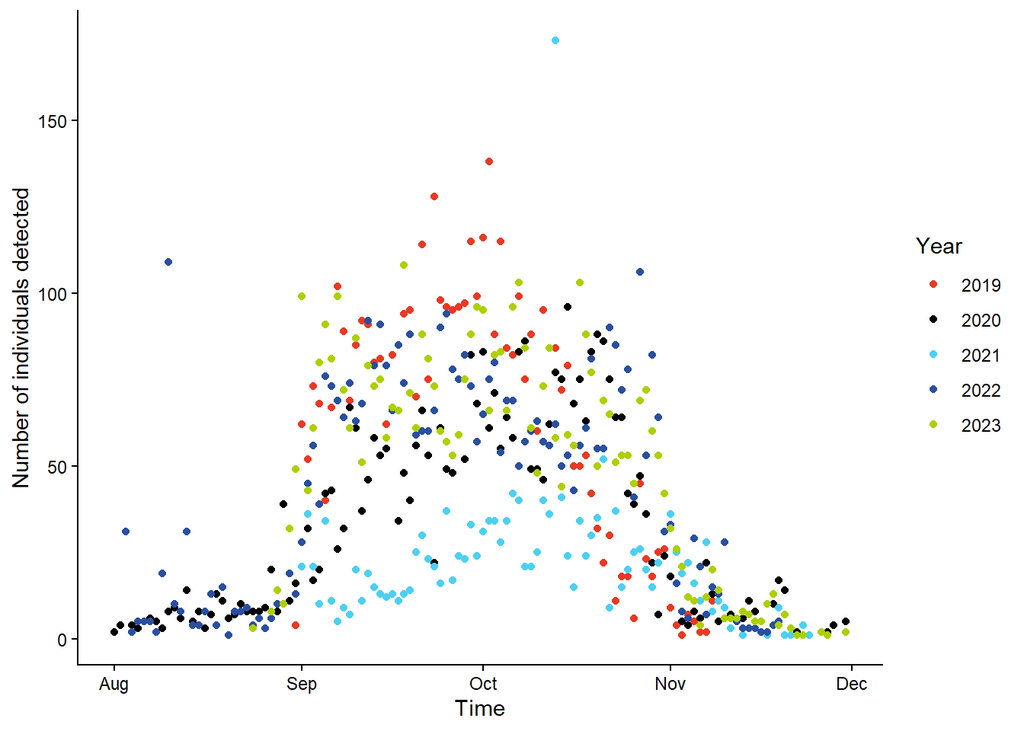

```r
wlf_time <- sp_time[sp_time$term != "human-domestic", ] %>%
  group_by(year, julian_day) %>% # group by year, then julian day
  summarise(n_individuals = sum(group_number)) # calculate number of individuals detected daily per year

ggplot(wlf_time, aes(x = julian_day,
                     y = n_individuals,
                     color = as.factor(year))) +
  geom_point() +
  labs(x = "Time", y = "Number of individuals detected", color = "Year") +
  scale_color_tanagr(palette_name = "tangara_chilensis") +
  theme_classic()
```

### 4.3.2 Wildlife and human-domestic detections over time

We want to visualize the number of individuals detected over time, along with the number of humans and domestic animals. We will first look at the year level.

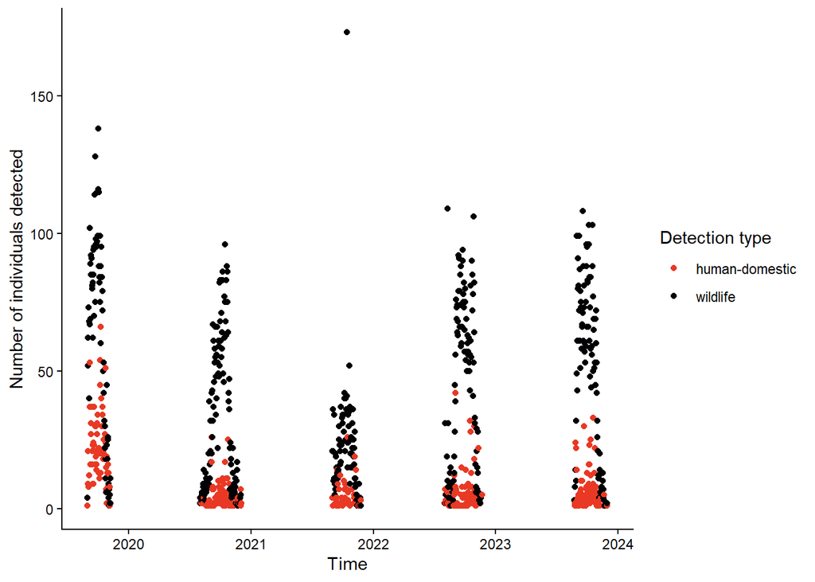

```r
wlf_human_time <- sp_time%>%
  group_by(date, term) %>% # group by date
  summarise(n_individuals = sum(group_number)) # calculate number of individuals detected daily across years

ggplot(wlf_human_time, aes(x = date,
                     y = n_individuals,
                     color = term)) +
  geom_point() +
  labs(x = "Time", y = "Number of individuals detected", color = "Detection type") +
  scale_color_tanagr(palette_name = "tangara_chilensis") +
  theme_classic()
```

Now, let’s look at a monthly level.

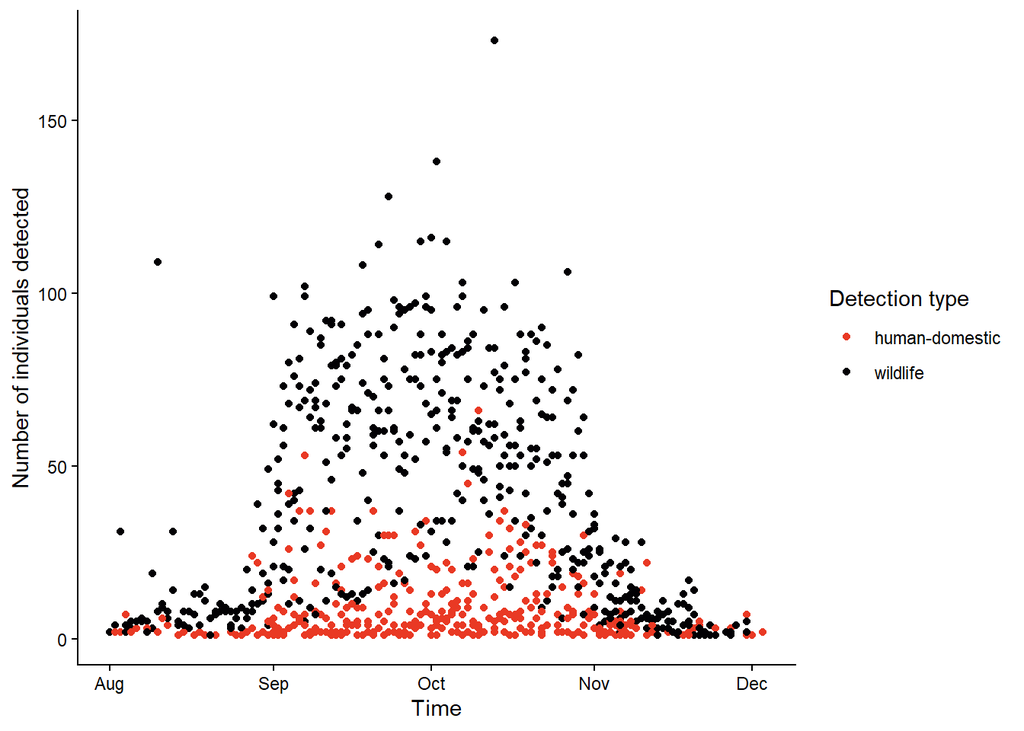

```r
wlf_human_julian <- sp_time%>%
  group_by(year, julian_day, term) %>% # group by year, then julian day, then term
  summarise(n_individuals = sum(group_number)) # calculate number of individuals detected daily per year

ggplot(wlf_human_julian, aes(x = julian_day,
                     y = n_individuals,
                     color = term)) +
  geom_point() +
  labs(x = "Time", y = "Number of individuals detected", color = "Detection type") +
  scale_color_tanagr(palette_name = "tangara_chilensis") +
  theme_classic()
```

Surprisingly, wildlife detections do not appear to decrease as human and domestic animal detections increase.